# Predict the manner of an individual performing a weight lifting exercise

Jathine Wong

November 20, 2015

## Objective

```
    The goal of this project is to build a model to predict the manner of an individual did his/her exercise.
    The data are from accelerometers on the belt, forearm, arm, and dumbell of 6 participants.
    They were asked to perform barbell lifts correctly and incorrectly in 5 different ways.
    We will select important features from the training data set, build a prediction model to predict the
    outcome of the provided test data set.
```

*Data Source*

```
    The training data for this project are available here:
            https://d396qusza40orc.cloudfront.net/predmachlearn/pml-training.csv

    The test data are available here:
            https://d396qusza40orc.cloudfront.net/predmachlearn/pml-testing.csv
```

*Training and Testing Data Sets*

We subset the provided training dataset further into a training set and a test set. We use the subsetted training set to select feature and to build a prediction model.

### Feature Selection

```
    The training data set contains 160 variables and 19622 observations.
    There are 67 columns have 98% missing data.
    These variables are uninformative and we will exclude them from the analysis.
    There are 34 variables with near zero variance, they will be excluded.
    We also remove the variable X, new_window, and columns with substring of _timestamp.
```

**Table 1 : Test for Near Zero Variance output**

```
##                           freqRatio percentUnique zeroVar   nzv
## X                          1.000000  100.00000000   FALSE FALSE
## user_name                  1.086168    0.04076641   FALSE FALSE
## raw_timestamp_part_1       1.100000    5.68691398   FALSE FALSE
## raw_timestamp_part_2       1.000000   88.53105041   FALSE FALSE
## cvtd_timestamp             1.016934    0.13588803   FALSE FALSE
## new_window                45.429022    0.01358880   FALSE  TRUE
## num_window                 1.100000    5.82959641   FALSE FALSE
## roll_belt                  1.117293    7.92227205   FALSE FALSE
## pitch_belt                 1.087591   11.69316483   FALSE FALSE
## yaw_belt                   1.012953   12.38619378   FALSE FALSE
## total_accel_belt           1.076187    0.18344884   FALSE FALSE
## kurtosis_roll_belt      2057.285714    2.11305884   FALSE  TRUE
## kurtosis_picth_belt      685.761905    1.72577796   FALSE  TRUE
## kurtosis_yaw_belt         45.429022    0.01358880   FALSE  TRUE
## skewness_roll_belt      2057.285714    2.10626444   FALSE  TRUE
## skewness_roll_belt.1     685.761905    1.84128278   FALSE  TRUE
## skewness_yaw_belt         45.429022    0.01358880   FALSE  TRUE
## max_yaw_belt             533.370370    0.40086968   FALSE  TRUE
## min_yaw_belt             533.370370    0.40086968   FALSE  TRUE
## amplitude_yaw_belt        47.528053    0.02717761   FALSE  TRUE
## gyros_belt_x               1.045410    0.91724419   FALSE FALSE
## gyros_belt_y               1.160526    0.44843049   FALSE FALSE
## gyros_belt_z               1.053184    1.12107623   FALSE FALSE
## accel_belt_x               1.060811    1.08030982   FALSE FALSE
## accel_belt_y               1.100862    0.94442180   FALSE FALSE
## accel_belt_z               1.085008    1.97717081   FALSE FALSE
## magnet_belt_x              1.131086    2.16061965   FALSE FALSE
## magnet_belt_y              1.131183    1.95678761   FALSE FALSE
## magnet_belt_z              1.051282    3.03030303   FALSE FALSE
## roll_arm                  52.612245   16.64628346   FALSE FALSE
## pitch_arm                 88.931034   19.29610001   FALSE FALSE
## yaw_arm                   33.480519   18.22258459   FALSE FALSE
## total_accel_arm            1.036254    0.44843049   FALSE FALSE
## gyros_arm_x                1.033679    4.32803370   FALSE FALSE
## gyros_arm_y                1.487113    2.50033972   FALSE FALSE
## gyros_arm_z                1.093671    1.61027313   FALSE FALSE
## accel_arm_x                1.014925    5.21810029   FALSE FALSE
## accel_arm_y                1.207792    3.61462155   FALSE FALSE
## accel_arm_z                1.159574    5.20451148   FALSE FALSE
```

[output cut: 39 more lines]

```
## skewness_yaw_forearm      45.429022    0.01358880   FALSE  TRUE
## max_yaw_forearm          236.081967    0.30574806   FALSE  TRUE
## min_yaw_forearm          236.081967    0.30574806   FALSE  TRUE
## amplitude_yaw_forearm     56.253906    0.02038320   FALSE  TRUE
## total_accel_forearm        1.126745    0.46201930   FALSE FALSE
## gyros_forearm_x            1.068796    1.96358201   FALSE FALSE
## gyros_forearm_y            1.020202    4.91914662   FALSE FALSE
## gyros_forearm_z            1.195965    1.99755402   FALSE FALSE
## accel_forearm_x            1.123077    5.27245550   FALSE FALSE
## accel_forearm_y            1.013158    6.65171898   FALSE FALSE
## accel_forearm_z            1.025641    3.82524800   FALSE FALSE
## magnet_forearm_x           1.035088    9.96059247   FALSE FALSE
## magnet_forearm_y           1.208955   12.50169860   FALSE FALSE
## magnet_forearm_z           1.090909   10.93898628   FALSE FALSE
## classe                     1.469452    0.03397201   FALSE FALSE
```

### Plot Features

Figure 1: Features of arms data.

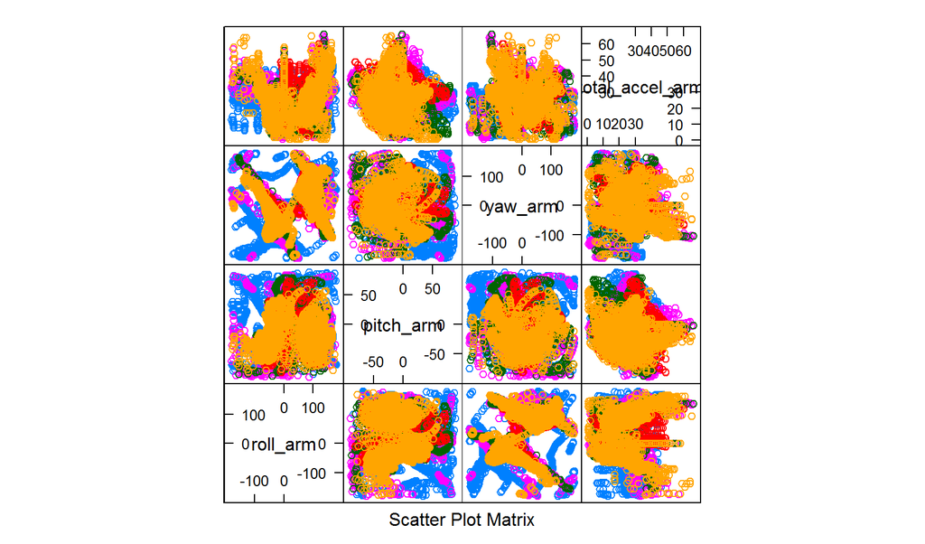

*Selected Feature Data Summary*

```
##     user_name      num_window      roll_belt        pitch_belt
##  adelmo  :2874   Min.   :  1.0   Min.   :-28.60   Min.   :-55.8000
##  carlitos:2380   1st Qu.:223.0   1st Qu.:  1.10   1st Qu.:  1.8425
##  charles :2646   Median :424.0   Median :112.00   Median :  5.3200
##  eurico  :2291   Mean   :430.7   Mean   : 63.92   Mean   :  0.4262
##  jeremy  :2578   3rd Qu.:644.0   3rd Qu.:123.00   3rd Qu.: 14.9000
##  pedro   :1949   Max.   :864.0   Max.   :162.00   Max.   : 60.3000
##     yaw_belt        total_accel_belt  gyros_belt_x
##  Min.   :-180.000   Min.   : 0.00    Min.   :-1.040000
##  1st Qu.: -88.300   1st Qu.: 3.00    1st Qu.:-0.050000
##  Median : -14.650   Median :17.00    Median : 0.030000
##  Mean   : -12.072   Mean   :11.25    Mean   :-0.005953
##  3rd Qu.:   9.935   3rd Qu.:18.00    3rd Qu.: 0.110000
##  Max.   : 179.000   Max.   :29.00    Max.   : 2.220000
##   gyros_belt_y       gyros_belt_z      accel_belt_x       accel_belt_y
##  Min.   :-0.53000   Min.   :-1.3500   Min.   :-120.000   Min.   :-65
##  1st Qu.: 0.00000   1st Qu.:-0.2000   1st Qu.: -21.000   1st Qu.:  3
##  Median : 0.02000   Median :-0.1000   Median : -15.000   Median : 32
##  Mean   : 0.03966   Mean   :-0.1289   Mean   :  -5.758   Mean   : 30
##  3rd Qu.: 0.11000   3rd Qu.: 0.0000   3rd Qu.:  -5.000   3rd Qu.: 61
##  Max.   : 0.64000   Max.   : 1.6200   Max.   :  83.000   Max.   :164
##   accel_belt_z     magnet_belt_x    magnet_belt_y   magnet_belt_z
##  Min.   :-275.00   Min.   :-52.00   Min.   :359.0   Min.   :-623.0
##  1st Qu.:-162.00   1st Qu.:  9.00   1st Qu.:581.0   1st Qu.:-375.0
##  Median :-150.00   Median : 35.00   Median :601.0   Median :-320.0
##  Mean   : -71.91   Mean   : 55.37   Mean   :593.6   Mean   :-345.6
##  3rd Qu.:  27.00   3rd Qu.: 59.00   3rd Qu.:610.0   3rd Qu.:-306.0
##  Max.   : 103.00   Max.   :485.00   Max.   :669.0   Max.   : 289.0
##     roll_arm         pitch_arm          yaw_arm          total_accel_arm
##  Min.   :-180.00   Min.   :-88.800   Min.   :-180.0000   Min.   : 1.00
##  1st Qu.: -31.10   1st Qu.:-25.875   1st Qu.: -43.1000   1st Qu.:17.00
##  Median :   0.00   Median :  0.000   Median :   0.0000   Median :27.00
##  Mean   :  18.30   Mean   : -4.617   Mean   :  -0.4406   Mean   :25.44
##  3rd Qu.:  77.47   3rd Qu.: 11.175   3rd Qu.:  46.2000   3rd Qu.:33.00
##  Max.   : 180.00   Max.   : 88.500   Max.   : 180.0000   Max.   :66.00
##   gyros_arm_x        gyros_arm_y      gyros_arm_z       accel_arm_x
##  Min.   :-6.37000   Min.   :-3.440   Min.   :-2.2800   Min.   :-383.00
##  1st Qu.:-1.33000   1st Qu.:-0.800   1st Qu.:-0.0800   1st Qu.:-242.00
##  Median : 0.06000   Median :-0.240   Median : 0.2300   Median : -45.00
##  Mean   : 0.03941   Mean   :-0.255   Mean   : 0.2653   Mean   : -61.24
```

[output cut: 50 more lines]

```
##  Max.   :311.00000   Max.   :231.0000   Max.   : 477.0   Max.   : 923.0
##  accel_forearm_z   magnet_forearm_x  magnet_forearm_y  magnet_forearm_z
##  Min.   :-446.00   Min.   :-1280.0   Min.   :-896.00   Min.   :-973.0
##  1st Qu.:-182.00   1st Qu.: -613.0   1st Qu.:  -8.75   1st Qu.: 196.2
##  Median : -42.00   Median : -374.0   Median : 589.00   Median : 508.5
##  Mean   : -56.30   Mean   : -310.3   Mean   : 376.91   Mean   : 394.8
##  3rd Qu.:  25.75   3rd Qu.:  -72.0   3rd Qu.: 737.00   3rd Qu.: 653.0
##  Max.   : 291.00   Max.   :  672.0   Max.   :1460.00   Max.   :1090.0
##  classe
##  A:4185
##  B:2848
##  C:2567
##  D:2412
##  E:2706
##
```

## Prediction Model

We examine two different prediction models, Boosting with PCA and Random Forest. We will record the performance time and the accuracy of both methods for comparison.

### Boosting with PCA Result

```
##    user  system elapsed
##  268.33    0.58  269.05
```

```
## Stochastic Gradient Boosting
##
## 14718 samples
##    13 predictor
##     5 classes: 'A', 'B', 'C', 'D', 'E'
##
## No pre-processing
## Resampling: Cross-Validated (10 fold)
## Summary of sample sizes: 13246, 13245, 13245, 13246, 13248, 13247, ...
## Resampling results across tuning parameters:
##
##   interaction.depth  n.trees  Accuracy   Kappa      Accuracy SD
##   1                   50      0.5305711  0.3983441  0.011351721
##   1                  100      0.5720826  0.4554693  0.015582613
##   1                  150      0.5896820  0.4787533  0.011327869
##   2                   50      0.6080248  0.5028274  0.011879245
##   2                  100      0.6695868  0.5816900  0.008501658
##   2                  150      0.7098089  0.6329126  0.011005712
##   3                   50      0.6627920  0.5732018  0.008822680
##   3                  100      0.7310786  0.6601842  0.010590597
##   3                  150      0.7689920  0.7079069  0.013621126
##   Kappa SD
##   0.01482055
##   0.02018065
##   0.01469018
##   0.01512868
##   0.01069115
##   0.01391500
##   0.01129414
##   0.01335508
##   0.01719905
##
## Tuning parameter 'shrinkage' was held constant at a value of 0.1
##
## Tuning parameter 'n.minobsinnode' was held constant at a value of 10
## Accuracy was used to select the optimal model using  the largest value.
## The final values used for the model were n.trees = 150,
##  interaction.depth = 3, shrinkage = 0.1 and n.minobsinnode = 10.
```

```
## [1] "GBM in sample error is 0.231"
```

*Apply the GBM model to the test set*

To predict the outcome of the test set, and to estimate the out of sample error

```
## Confusion Matrix and Statistics
##
##           Reference
## Prediction    A    B    C    D    E
##          A 1161   44   75   93   22
##          B   68  683  120   42   36
##          C   63   67  689   28    8
##          D   41   53  111  587   12
##          E   39   79   75   42  666
##
## Overall Statistics
##
##                Accuracy : 0.772
##                  95% CI : (0.76, 0.7837)
##     No Information Rate : 0.2798
##     P-Value [Acc > NIR] : < 2.2e-16
##
##                   Kappa : 0.712
##  Mcnemar's Test P-Value : < 2.2e-16
##
## Statistics by Class:
##
##                      Class: A Class: B Class: C Class: D Class: E
## Sensitivity            0.8462   0.7376   0.6439   0.7412   0.8952
## Specificity            0.9337   0.9331   0.9567   0.9472   0.9435
## Pos Pred Value         0.8323   0.7197   0.8058   0.7301   0.7392
## Neg Pred Value         0.9399   0.9386   0.9059   0.9500   0.9805
## Prevalence             0.2798   0.1888   0.2182   0.1615   0.1517
## Detection Rate         0.2367   0.1393   0.1405   0.1197   0.1358
## Detection Prevalence   0.2845   0.1935   0.1743   0.1639   0.1837
## Balanced Accuracy      0.8900   0.8354   0.8003   0.8442   0.9193
```

```
## [1] "GBM out of sample error is 0.228"
```

*Figure 2 : Boosting Resampling Profile*

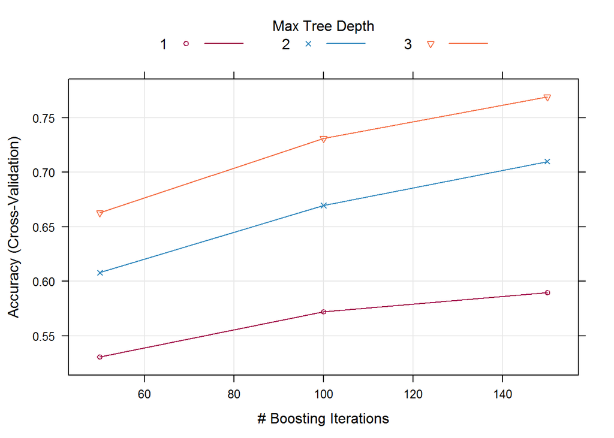

### Random Forest Result

We use Random forest with cross validation from train function to reduce overfitting

```
##    user  system elapsed
## 1184.61    5.06 1190.86
```

```
## Random Forest
##
## 14718 samples
##    54 predictor
##     5 classes: 'A', 'B', 'C', 'D', 'E'
##
## No pre-processing
## Resampling: Cross-Validated (10 fold)
## Summary of sample sizes: 13246, 13245, 13245, 13246, 13248, 13247, ...
## Resampling results across tuning parameters:
##
##   mtry  Accuracy  Kappa  Accuracy SD  Kappa SD
##    2    0.995     0.993  0.00290      0.00367
##   30    0.997     0.997  0.00264      0.00334
##   58    0.995     0.994  0.00317      0.00401
##
## Accuracy was used to select the optimal model using  the largest value.
## The final value used for the model was mtry = 30.
```

```
##
## Call:
##  randomForest(x = x, y = y, mtry = param$mtry)
##                Type of random forest: classification
##                      Number of trees: 500
## No. of variables tried at each split: 30
##
##         OOB estimate of  error rate: 0.14%
## Confusion matrix:
##      A    B    C    D    E  class.error
## A 4183    1    0    0    1 0.0004778973
## B    4 2842    2    0    0 0.0021067416
## C    0    4 2563    0    0 0.0015582392
## D    0    0    6 2405    1 0.0029021559
## E    0    0    0    2 2704 0.0007390983
```

```
## [1] "Random Forest in sample error is 0.0026"
```

*Apply the Random Forest model to the test set*

To predict the outcome and to estimate the out of sample error

```
##
## pred.test    A    B    C    D    E
##         A 1395    1    0    0    0
##         B    0  943    1    0    0
##         C    0    4  854    5    0
##         D    0    1    0  799    1
##         E    0    0    0    0  900
```

```
## [1] "Random Forest out of sample error is 0.0027"
```

## Final Model

### Predicting Results of the provided test set

```
    . Apply the feature selection to the test set

    . We use the Random Forest Model to predict the test data set outcome
```

```
##  [1] B A B A A E D B A A B C B A E E A B B B
## Levels: A B C D E
```

## Diagnostic

We will examine some of the interesting features from the training data set

**Figure 3 : We take a look at the top 20 important variables used in the random forest model**

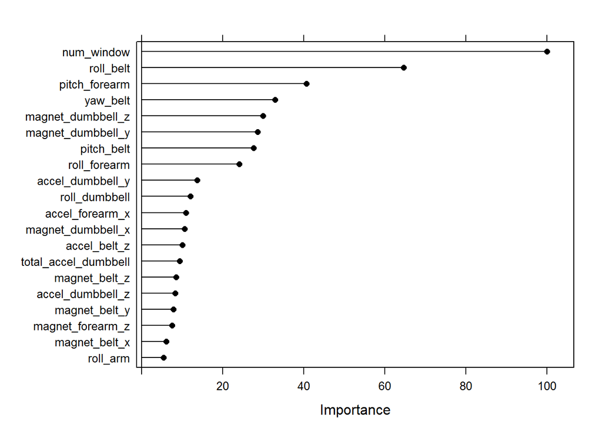

**Figure 4 : Classe A gyros_arm_x data is less widely spread then the other 4 classes**

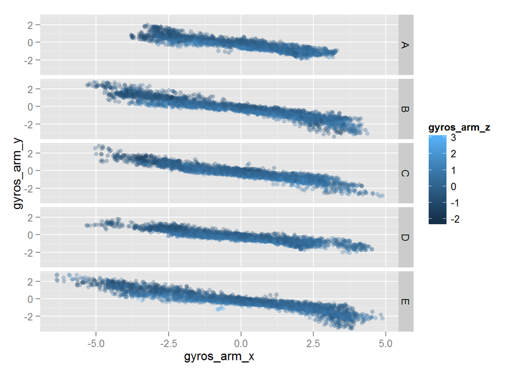

**Figure 5 : Box plots of gyros arms position data**

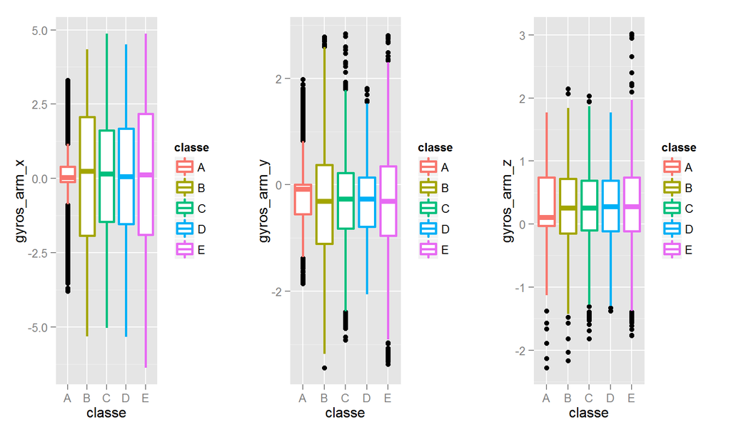